# Unlocking Insights: Predictive Modeling of Anime Show Scores

Final Project  
Data Science 2 with R (STAT 301-2)

Author

Sana Nanlawala

Published

March 14, 2024

**Github Repo Link**

[This is the github repository containing all details and work related to this report.](https://github.com/stat301-2-2024-winter/final-project-2-SanaNanlawala2026.git)

# Introduction:

The dataset that this report focuses on is data collected on nearly 15,000 animes. Anime is a popular form of entertainment that originates from Japan and the purpose of this report is to focus on creating a **regression** model the predicts the score an anime receives, which is essentially a culmination of audience reviews and ratings for the show. Building a predictive model built around the ratings that were given to the animes in this dataset was chosen as a focus of this report because there are a lot of examples of similar models surrounding movies and television in the global west, like the Netflix Prize dataset for modelling user ratings predictions for example. It would be interesting to see how it would hold up for anime, which has an entirely demographic of viewers/audience, especially in age and nationality.

# Data Overview:

The dataset is sourced from Kaggle and contains 14,949 observations. The dependent variable being focused on predicting in this modeling report is the the rating score that each anime receives.

## Exploration of Target Variable

The anime score is a numeric variable that is generally between the values 1-10, where 10 would be the highest score the anime receives. A preliminary glance at the distribution in Figure 1 shows that most of the scores lie somewhere between 6 and 7.5.

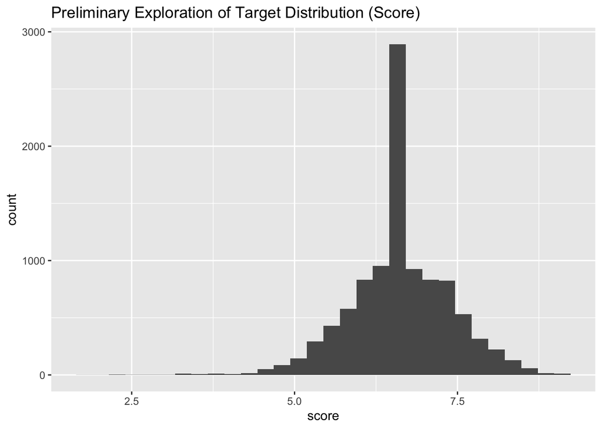

Figure 1: Initial Score Exploration

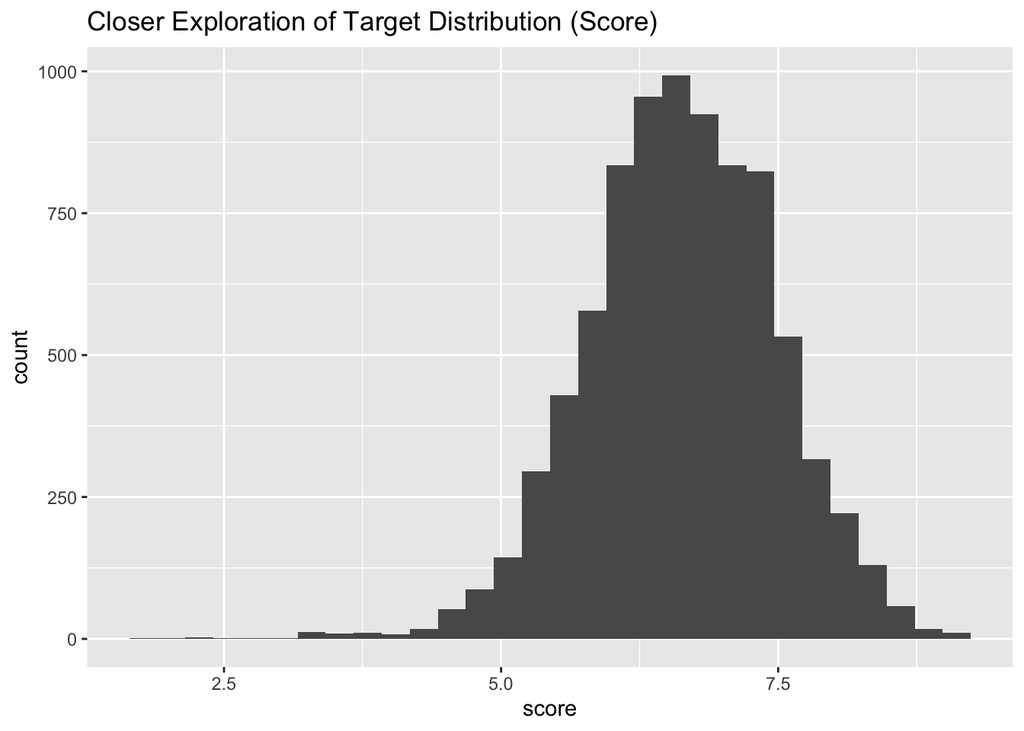

Figure 2: Further Score Exploration

## Missingness

The dataset contained no missing values for the score values that are being predicted with the models. However there was some missingness in the other variables, the ones being used to predict. Below shows the missingness of the the duration of each anime (minutes per episode, or minutes in the movie), the number of episodes, and the ranking given to the anime.

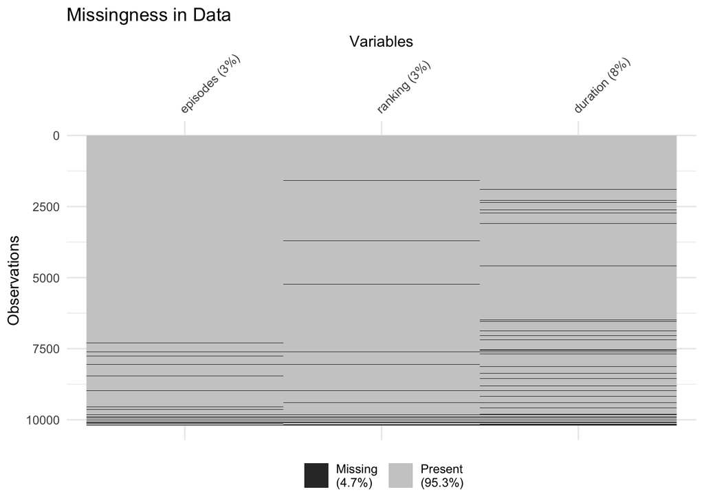

Figure 3: Missingness

The missingness in Figure 3 will be addressed in the recipes used for the models, where the missing values will be imputed by the mean values of the variables.

# Methods:

## Data Splitting

The choice to split the cleaned dataset was done with 70% of the data being subsetted for the training portion of the modeling process and 30% of the data being utilized as the testing data, which after fitting the best, most accurate, predictive model onto the training set, would be used to predict on the testing subset. The proportions were ultimately decided for both computational reasons, in that the computer used to run models would be able to handle this, as well as the size of the dataset, which was large enough that allocating 70% of the data to the training set would be sufficient for the model to have enough data to “learn” from. Also the proportion on this dataset was chosen best to avoid giving too little data to the training set to avoid issues such as overfitting.

## Different Models

This report explains the performance of six models, where five of them were run on two different recipes. (for a total of 11 models) Since this is a regression model, the six chosen models used are listed below:

- Null Model: This was chosen as a baseline model, using a parametric baseline recipe, with no extreme expectations on its performance.
- LM Model: The linear regression model was run twice, once on a baseline/kitchen sink recipe, and once on a more complex, feature-engineered recipe.
- Boosted Tree Model: The boosted tree model was run twice, once on a baseline/kitchen sink recipe, and once on a more complex, feature-engineered recipe.
- Elastic Net Model: The elastic net model was run twice, once on a baseline/kitchen sink recipe, and once on a more complex, feature-engineered recipe.
- K-Nearest Neighbors Model: The K-Nearest Neighbors Model was run twice, once on a baseline/kitchen sink recipe, and once on a more complex, feature-engineered recipe.
- Random Forest Model: The Random Forest Model was run twice, once on a baseline/kitchen sink recipe, and once on a more complex, feature-engineered recipe.

## Recipe Building

### Baseline / Kitchen Sink Recipe:

1. The first step taken in building this recipe was to remove unwanted variables when fitting the models. This specifically included variables that were entirely unique, and served to “ID” each observation, which in this case was the title of the anime. In previous steps of the data cleaning process, other similar variables–such as the synopsis–were already filtered out of the dataset so it did not need to be removed within the recipe.
2. Next was converting categorical numeric variables into dummy variables or binary indicators. While in the data cleaning process, some variables that had an extensive amount of categories (such as genre rating and the source material of the anime) were already split by their factors and turned into binary predictors, other variables such as the type of anime (TV, OVA, etc.) needed to be manipulated in this step of the recipe. This is because commonly, model algorithms need to take in numerical input, and including this within a recipe is a more efficient method of allowing for this.
3. The next step was to center all numeric predictor variables which involved the process of subtracting the mean value of the variable. Normalizing the numeric predictors allows for a mean of zero, making the variable values more comparable across different scales in the different models.
4. Another step for normalizing the numeric predictors was by scaling them so that the variables all have a standard deviation of one. This ensures that variables with significantly different or large ranges are not negatively influencing the model.
5. Lastly, to deal with missingness across the predictor variables, the missing values need to be imputed with the mean value of the corresponding variable.

Two versions of the kitchen sink recipe were created. One that fits parametric models such as linear regression and elastic net model. To fit the other tree-based models mentioned earlier, certain steps were altered to better fit a tree model. Specifically when turning categorical variables into dummy variables, one-hot encoding was used where each category of a categorical variable was represented by its own binary indicator variable. This ensures that these tree models preserve and utilize the categorical information without assuming any specific relationship between categories.

### Feature Engineered Recipe:

The feature engineered recipes were made for both trees and parametric models but the only difference was as mentioned above, with the one-hot encoding for the dummy variables. The main focus of the feature engineering was creating interaction between predictors. Part of the EDA process was to find correlations between predictors, specifically the number of episodes, the duration of each episodes, and the ranking. There was a high correlation with with the ranking and score, which makes sense as a score given to anime should likely correlate to the ranking its given as well. However, it was not included in the recipe as the predictions would not have included the outcome/target variable anyway.

There was a correlation of -0.2054627 between the duration of each episodes and the ranking. While this is not a high correlation, studies have shown that shorter length episodes are becoming the norm as more and more people have shorter attention spans. This was previously more common in children television, which is the primary audience of anime, but is now also becoming more common in adult television as well (Jones Medium). Therefore the interaction between the two variables were included in the feature engineering part of the recipe. More information on this study is located in the references section at the bottom of this report.

The correlation between ranking and number of episodes was 0.005810827 which shows almost no correlation. However, the feature engineered recipe still included a step that correlatted and focused on the interaction between the ranking of the anime and the number of episodes because generally, well-liked television tends to run for longer seasons, and therefore more episodes, as production companies continue to air the show.

## Resampling Method:

The resampling method used in the models was v-fold cross validation. This specific process separated the data a ‘v’ number of folds containing a nearly equal amount of data. For this specific dataset, 5 folds were created, meaning 80% of the training data was used to fit the different models. This was chosen so that with the process of cross-validation, fitting models on the folds would help evaluate and tune the hyperparameters best for each model. More specifically, the cross-validation was set to repeat 3 times where each repetition generated a new random partitioning of the data into the folds. By repeating the cross-validation, it reduces variability in the performance estimates.

## Performance Metric

The chosen metric to evaluate the performance of each model was root mean squared error, also known as RMSE. RMSE was chosen as the performance metric to choose the best model largely because it penalizes heavier/larger errors than most metrics. Its units are the units of the outcome being predicted, which in this case is the score the anime receives. The best model is chosen by having the lowest RMSE value, indicating the predicted values of the model are close to the actual values (an therefore a smaller error).

## Tuning

The tuning process for each model required the creation of a tuning grid. For the sake of computational efficiency, a tuning grid with five levels was chosen.

The models where hyperparameter-tuning was focused on are detailed below. The two linear models and the null model did not have any hyperparameters that were tuned or updated.

### Elastic Net Model

*Kitchen Sink*

The parameters that were tuned for the elastic net model was the penalty and mixture parameters. The iterations of tuning were done first on the model using the kitchen sink recipe, then the optimal ranges were used on the feature-engineered model. On the first round of tuning, default ranges were fitted into the model:

- Penalty (Amount of Regularization) : (-10,0)
- Mixture (Proportion of Lasso Penalty) : (0,1)

After performing the tuning process, which involved fitting the different sets of hyperparameters onto the folds and evaluating their performance using cross-validation, below in Figure 4 is a plot that summarizes the performance of the model across different hyperparameter values.

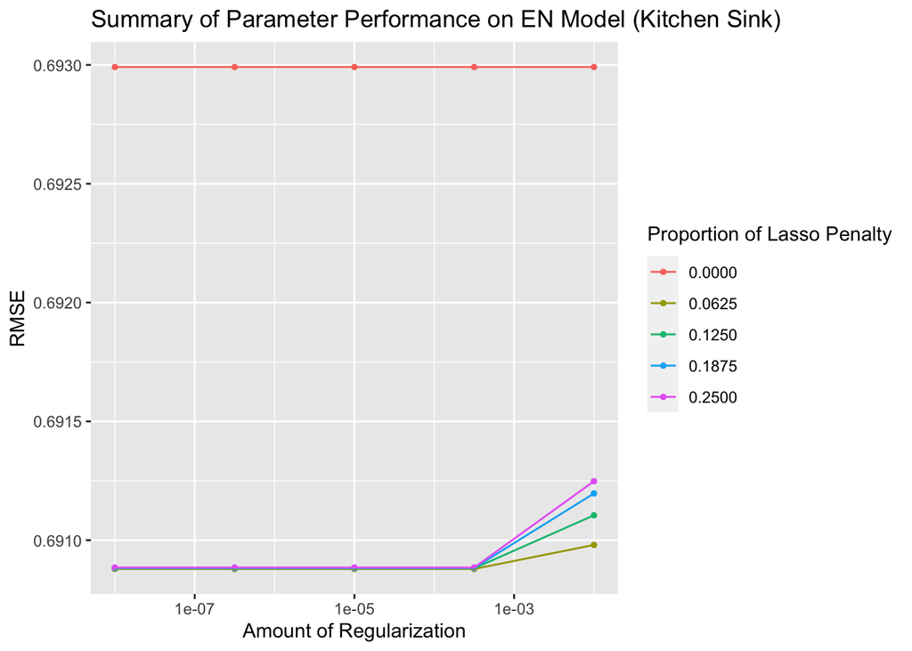

Figure 4: Autoplot Performance

Looking at Figure 4 above, one is able to see that the smallest possible value of RMSE is reached by the parameter ranges tuned on the folds. The RMSE value begins to increase at about a 0.001 value of penalty and the lowest RMSE value is at values of mixture greature than 0.

The cross validation process involved finding the best possible tuning parameters and the measure of the performance metric, which in this case is RMSE. Below in Table 1 are the values for the elastic net model used on the base line recipe.

Table 1: Best Parameters

| RMSE value | penalty | mixture | Standard Error |
| --- | --- | --- | --- |
| 0.690879 | 0 | 0.0625 | 0.0030836 |

*Feature-Engineered*

Following the tuning of the elastic net model on the kitchen sink recipe, the same tuning range was used elastic net model with the feature engineered recipe. Below in Figure 5 is a plot of the performance:

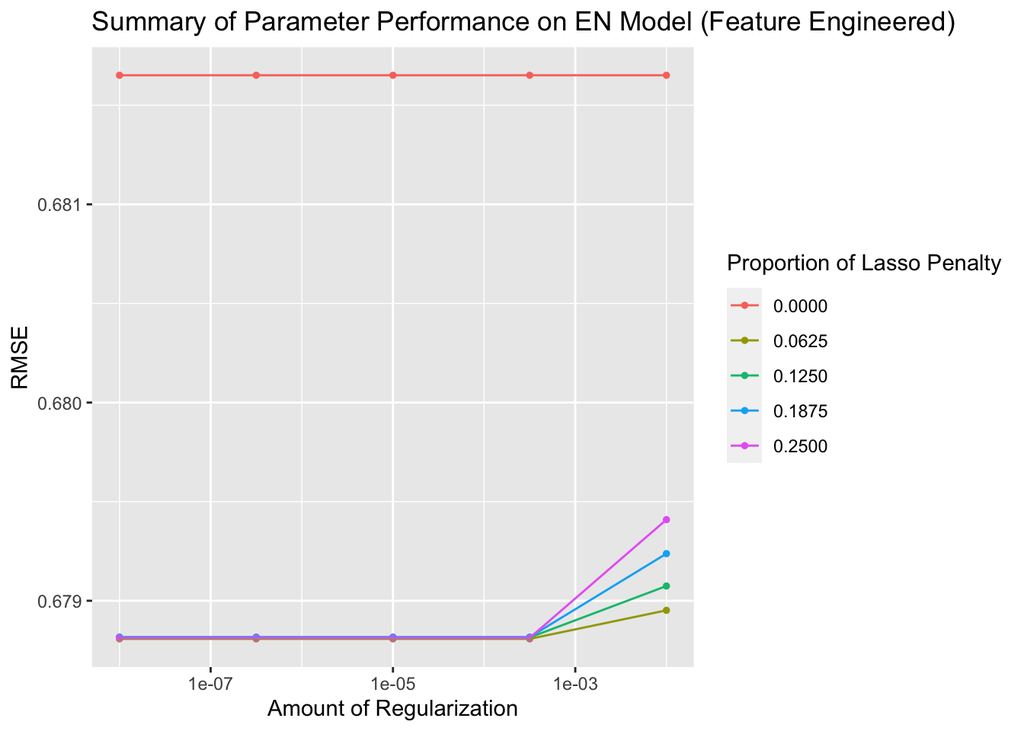

Figure 5: Autoplot Performance

The performance of the parameter ranges above in Figure 5 was extremely identical to the performance on the previous fitting of the kitchen sink recipe. Following this, the best values for the parameters are listed below in Table 2:

Table 2: Best Parameters

| RMSE value | penalty | mixture | Standard Error |
| --- | --- | --- | --- |
| 0.6788077 | 0 | 0.0625 | 0.0038787 |

### K-Nearest Neighbor Model

*Kitchen Sink*

The parameter that were tuned for the k-nearest neighbor model was the number of neighbors. The iterations of tuning were done first on the model using the kitchen sink recipe, then the optimal ranges were used on the feature-engineered model. On the first round of tuning, default ranges were fitted into the model:

- Neighbors (Nearest Neighbors) : (3,10)

After performing the tuning process, which involved fitting the different sets of hyperparameters onto the folds and evaluating their performance using cross-validation, below Figure 6 summarizes the performance of the model across different hyperparameter values.

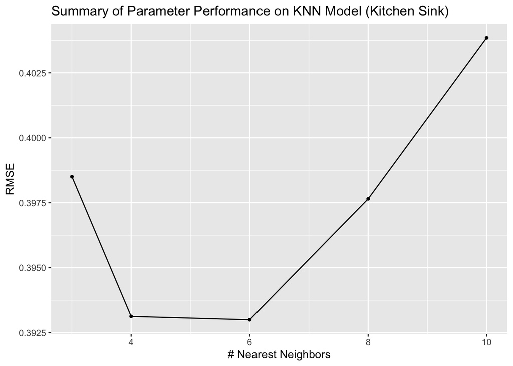

Figure 6: Autoplot Performance

From Figure 6 above, we are able to see that the lowest RMSE is found between the values of 4 and 6 neighbors so in this situation, the decision to do another round/iteration of tuning was not needed as the earlier ranges included values that gave the lowest RMSE.

Below in Table 3 are the best tuning parameters for the KNN fitting on the kitchen sink recipe where the result gives the lowest RMSE.

Table 3: Best Parameters

| RMSE value | neighbors | Standard Error |
| --- | --- | --- |
| 0.3929969 | 6 | 0.0074309 |

*Feature-Engineered*

For the feature engineered recipe, the range of (3,10) was kept in the first round of tuning. Below in Figure 7 is an autoplot of its performance.

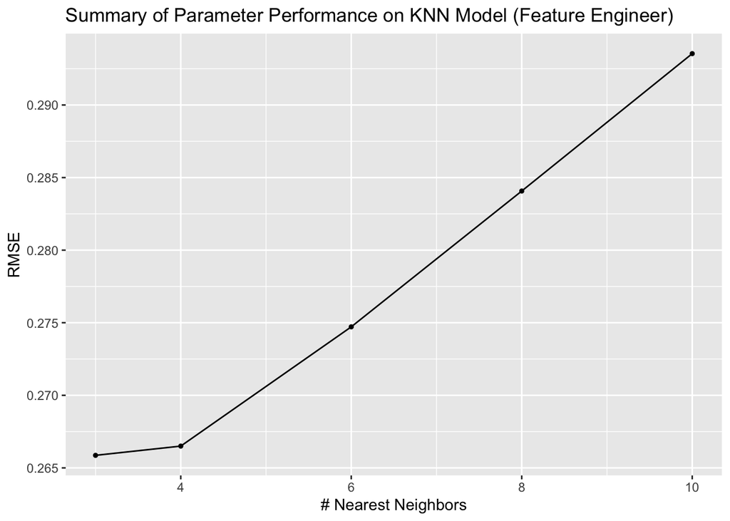

Figure 7: Autoplot Performance

The decision to do another round of tuning was taken because, the left side of Figure 7 showed a steady decrease of the RMSE value as the number of neighbors decreased. The tuning range for number of neighbors was then **widened to (1,10)**. Below Figure 8 is the plot showing its performance.

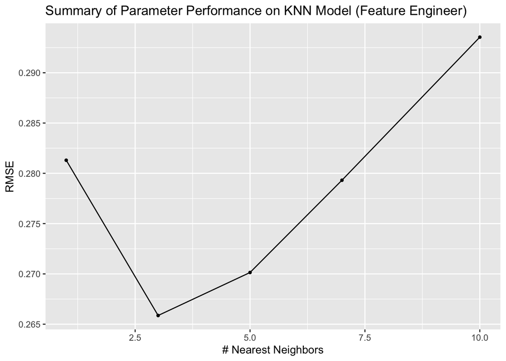

Figure 8: Autoplot Performance

The lowest possible RMSE is better highlighted in Figure 8 within this tuning range and so further rounds of tuning were not done. Below, Table 4 shows the best tuning parameters for the KNN fitting on the feature-engineered recipe where the result gives the lowest RMSE.

Table 4: Best Parameters

| RMSE value | neighbors | Standard Error |
| --- | --- | --- |
| 0.2658646 | 3 | 0.0129068 |

### Random Forest Model

*Kitchen Sink*

The parameters that were tuned for the random forest model were the minimal node size (min_n) and the number of predictors to try at each split when constructing a decision tree within the random forest (mtry). The number of trees was also a point of tuning, but was not explored within this report due to computational reasons, and was therefore kept at a constant of 1000 trees, to maximize the efficiency of run time for each fitting of the model. The iterations of tuning were done first on the model using the kitchen sink recipe, then the optimal ranges were used on the feature-engineered model. On the first round of tuning, default ranges were fitted into the model:

- min_n (Minimal Node Size) : (1,10)
- mtry (Randomly Selected Predictors) : (1,5)

Five, as the upper end of the mtry range, was chosen because it represented the square root of the number of predictors used in the model.

Below, Figure 9 summarizes the performance of the model across different hyperparameter values.

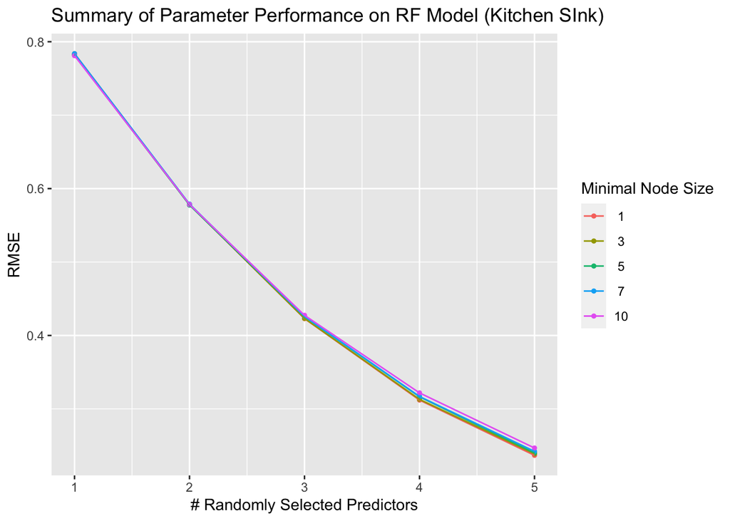

Figure 9: Autoplot Performance

Below, Figure 10 is the performance of the new round of tuning.

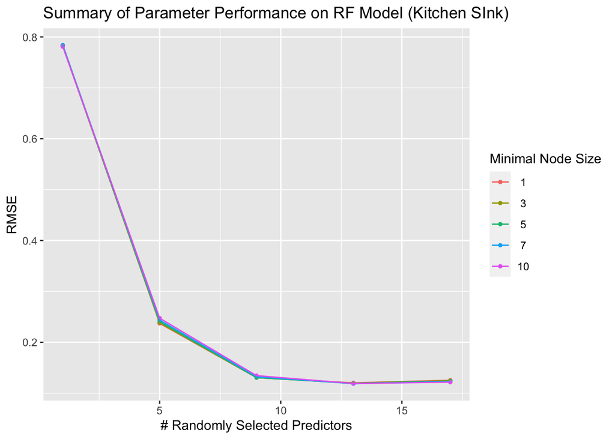

Figure 10: Autoplot Performance

Table 5: Best Parameters

| RMSE value | min_n | mtry | Standard Error |
| --- | --- | --- | --- |
| 0.1186796 | 7 | 13 | 0.0133944 |

*Feature Engineered*

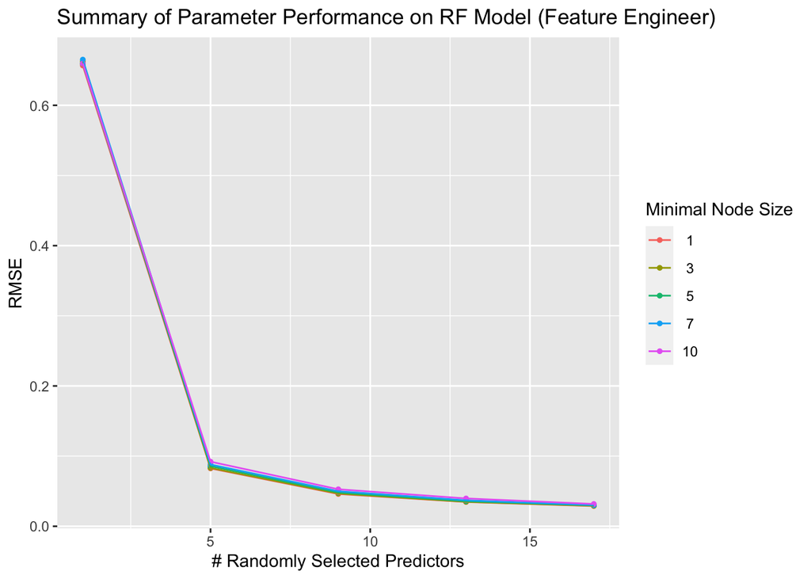

Figure 11: Autoplot Performance

Table 6: Best Parameters

[output not shown]

### Boosted Tree Model

*Kitchen Sink*

The parameters that were tuned for the boosted tree model were the minimal node size (min_n), learn rate, and the number of predictors to try at each split when constructing a decision tree within the random forest (mtry). The iterations of tuning were done first on the model using the kitchen sink recipe, then the optimal ranges were used on the feature-engineered model. On the first round of tuning, default ranges were fitted into the model:

- min_n (Minimal Node Size) : (1,10)
- mtry (Randomly Selected Predictors) : (1,4)
- learn rate : (-10,-1)

Figure 12 is the performance of the first round of tuning, fitting the kitchen sink tree recipe on a boosted tree model.

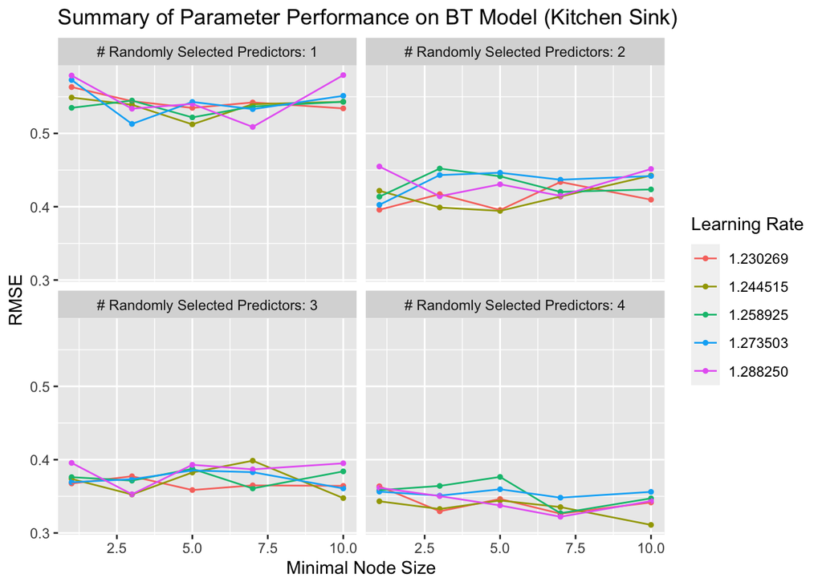

Figure 12: Autoplot Performance

While it is hard to distinguish any relation between RMSE values and each parameter in Figure 12, further tuning was done to each parameter at a time to evaluate how they each affect the performance. When changing the parameter of the minimal node size, little change was done to the RMSE value, so mtry and learning rate needed to be tuned next. The next round of tuning **changed the learn rate range to (0.09,0.11).** Below, Figure 13 shows the performance of the second round of tuning.

[figure not shown]

Figure 13: Autoplot Performance

Table 7: Best Parameters

| RMSE value | min_n | mtry | learn_rate | Standard Error |
| --- | --- | --- | --- | --- |
| 0.3263092 | 7 | 4 | 1.230269 | 0.0155126 |

*Feature Engineered*

The previous ranges used on the kitchen sink model were used as for the first round of tuning on the boosted tree, feature engineered model. Below, Figure 14 shows the performance on this fitting.

[figure not shown]

Figure 14: Autoplot Performance

Table 8: Best Parameters

| RMSE value | min_n | mtry | learn_rate | Standard Error |
| --- | --- | --- | --- | --- |
| 0.2402337 | 5 | 4 | 1.230269 | 0.0185151 |

# Model Building & Selection:

To reiterate, RMSE was the chosen metric to evaluate the performance of the different models. When fitting both kitchen sink and feature engineered recipe on the different models, the RMSE values were always lower on the feature engineered models. Table 9 shows the RMSEs for each model, including the null model and the two linear models.

Table 9: RMSE Table

| Model | RMSE value | Standard Error |
| --- | --- | --- |
| RF (feature-engineered recipe) | 0.0855291 | 0.0095027 |
| RF (base recipe) | 0.1186796 | 0.0133944 |
| BT (feature-engineered recipe) | 0.2402337 | 0.0185151 |
| KNN (feature-engineered recipe) | 0.2658646 | 0.0129068 |
| BT (base recipe) | 0.3263092 | 0.0155126 |
| KNN (base recipe) | 0.3929969 | 0.0074309 |
| EN (feature-engineered recipe) | 0.6788077 | 0.0038787 |
| LM (feature-engineered recipe) | 0.6788179 | 0.0038802 |
| EN (base recipe) | 0.6908790 | 0.0030836 |
| LM (base recipe) | 0.6908803 | 0.0030582 |
| Null (base recipe) | 0.9999290 | 0.0041575 |

Again, in Table 9 we can see that feature-engineered models did better than their corresponding kitchen sink model. This shows that the extra steps added to the recipe, such as removing more predictors and creating interactions between other predictors, helped the model’s performance. **The winning model was the random forest model, using the feature-engineered recipe.** This is because it had the lowest RMSE value, meaning this model’s predictions will be the most accurate. Below, Table 10 reiterates the best tuning parameters for this model.

Table 10: Final Model Parameters

| RMSE value | min_n | mtry | Standard Error |
| --- | --- | --- | --- |
| 0.0855291 | 7 | 13 | 0.0095027 |

The random forest models generally performing better than any other model was not entirely surprising as random forests are better capable of capturing non-linear relationships between predictors and the target variable, making them suitable for this dataset that had many non-linear relationships between the outcome of score and other variables that measured episode duration, number of episodes, genres, and ratings! Also, as mentioned earlier, the number of trees was left constant throughout this whole process of tuning due to computational efficiency reasons, so this may create another avenue of tuning and further exploration as more trees help overcome the limitations of single-tree models that do not necessarily have the best predictive accuracy!

# Final Model Analysis:

Following the selection of the best model, the entire training data set was fitted onto the random forest model with the feature engineered recipe. This final fitting was then use to test on the testing data and create predicted values to compare with. Figure 15 shows a scatterplot comparing the predicted values versus the actual values of the anime score on the testing data.

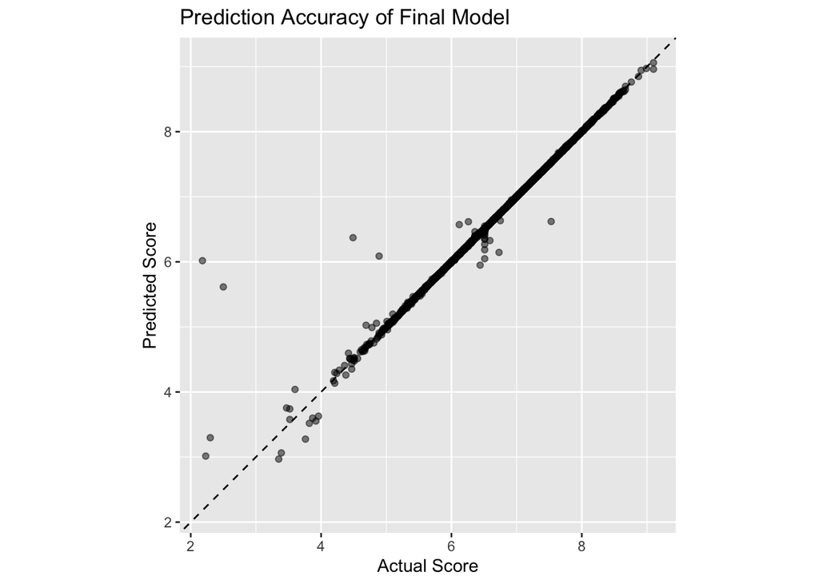

Figure 15: Prediction Accuracy of Final Model

Figure 15 shows how nearly all the predicted values were accurate with a line of best fit that shows the actual score equals the predicted score!

Table 11 shows the performance metrics of RMSE, R^2 (R-Squared), and MAE (Mean Absolute Error) on the final model!

Table 11: Final Model Metrics Performance

| Performance Metric | Value |
| --- | --- |
| rmse | 0.1068645 |
| mae | 0.0102198 |
| rsq | 0.9813713 |

The results of these performance metrics are surprisingly well performing, with a very low RMSE value of 0.107, (still low in comparison to the other models), meaning the predicted values are not far off from the actual values of the testing data. The R^2 value, which ranges from 0-1, is 0.98 which means it explains almost all of the variability of the data around its mean. MAE is similar to RMSE in that the units are the same as the score the anime received and evaluates the average absolute difference between the predicted values and the actual values in the dataset. Since the MAE value was extremely small, at 0.01, this is a good performance of the model as the difference between the predicted values and the actual values was small.

# Conclusion:

In conclusion, the predictive modeling approach applied to anime show scores yields promising results, with the Random Forest model outperforming other models. This analysis provides valuable insights into the factors influencing anime scores and demonstrates the applicability of data science techniques in understanding audience preferences in the anime industry. The steps taken in feature engineering and tuning the parameters also played a positive role in affecting the performance of the models, paving the way for further avenues of exploration that was not addressed in this report! Examining other parameters, such as the number of trees (especially since the winning model was a random forest model) is one thing to further explore. Adjusting the levels of the tuning grid may also be an option, especially by increasing the number. Another avenue may be looking into more complex recipes with feature engineering that looks at more interactions or possible transformations!

Overall, this analysis not only provides valuable insights into the determinants of anime scores but also underscores the applicability of data science techniques in deciphering audience preferences within the anime industry. By leveraging advanced modeling approaches and rigorous methodology, this study sets the stage for further exploration and refinement, paving the way for continued advancements in predictive analytics within the realm of anime show scoring prediction.

# References:

Sajid. “Anime Dataset 2023.” Kaggle, 28 July 2023, www.kaggle.com/datasets/dbdmobile/myanimelist-dataset?select=anime-filtered.csv.

Watson, Leon. “Humans Have Shorter Attention Span than Goldfish, Thanks to Smartphones.” The Telegraph, Telegraph Media Group, 12 Mar. 2016, www.telegraph.co.uk/science/2016/03/12/humans-have-shorter-attention-span-than-goldfish-thanks-to-smart/.

Writer, Jones the. “How Long Should TV Shows Be? The Rise of Shorter TV.” Medium, Medium, 24 Nov. 2019, joneswriter.medium.com/how-long-should-tv-shows-be-the-rise-of-shorter-tv-6f23a83d572d.